# Satisfacción con la democracia en países de América

Roque Alfaro, Sebastian Cortinez, Kevin Carrasco, Francisco Delgado

14 de octubre de 2019

# 1 Abstract

# 2 Introducción

Durante la segunda mitad del siglo XX, los países de América, específicamente América latina y el Caribe, experimentaron procesos de democratización en sus territorios generando que se consolide la democracia como sistema de gobierno, reemplazando al autoritarismo que se había establecido, en su gran mayoría, por dictaduras militares. Este régimen, se instaló de manera generalizada en América Latina por primera vez en su historia (Garretón Merino, 2014). La democracia, entendiendo por ello como un sistema de gobierno, fue el principal elemento en el proceso de modernización en los países de Latinoamérica, debido a la legitimidad política que adquiere en la época actual (Alister, Cea, & Guerrero, n.d.). De esta manera, las democracias se han afianzado en la región por el peso de variables tanto internas como externas. Por un lado, las primeras refieren a que este régimen se consolidó al interior de los países producto de la promesa de que este sistema traería consigo cambios positivos en diferentes facetas de la vida ciudadana (Olmeda, 2019). Por otro lado, las segundas refieren a que se ve influenciada “por la globalización, instituciones internacionales y el sistema económico mundial”. (Alister et al., n.d., p. 87)

Sin embargo, en la actualidad, la democracia ha experimentado una profunda deslegitimación por parte de los ciudadanos, expresándose en un bajo nivel de satisfacción -o insatisfacción- de democracia que observan en sus respectivos países (Olmeda, 2019). Lo anterior guarda relación con que los regímenes democráticos se instalaron en América Latina al alero de una crisis política, que refiere a la pérdida de legitimidad para organizar la vida en común, del principio de representación y de su capacidad de dar un sentido colectivo (Garretón Merino, 2014). Además, este bajo nivel de satisfacción es generada por la mala gestión de los gobiernos, la promoción de políticas gubernamentales que no generan mejoras en los aspectos de la vida de los ciudadanos y las violencias con las que se imponen y se mantienen las democracias en Latinoamérica. Estas características se engloban en un proceso denominado “desorden democrático” (Sánchez, 2004). En este sentido, también hay otros factores que inciden en los niveles de la satisfacción con la democracia, como la corrupción, puesto que tiene un impacto significativo en la calidad de las democracias y en el desarrollo de los paises de Latinoamerica (Ramos & Álvarez, 2019). Asimismo, el desarrollo económico de cada país guarda relación con la satisfacción de los niveles de democracia, ya que el desarrollo sostenido de la economía le otorga legitimidad y estabilidad (Diamond, 1992)

Con respecto a estudios anteriores, referidos al declive de la confianza en la democracia en América Latina, se pueden nombrar “El control de la corrupcion de America Latina” (Ramos & Álvarez, 2019), que refieren a cómo la corrupción impacta en la percepción de los ciudadanos respecto a las agendas políticas de los distintos países de la región. En esa misma línea, se puede nombrar “Corrupción en América Latina: entendiendo la brecha percepción-exposición” (Bohn, 2012), que explica la diferencia entre percepción y exposición a la corrupción, siendo la primera la que disminuye significativamente la satisfacción de los ciudadanos con la democracia, mientras que la última no lo hace.

Otro estudio que se relaciona es “Corrupción y Democracia” (Morales Quiroga, 2009), el cual se suma a que existe un amplio consenso de que la corrupción tiene un impacto negativo en la democracia, pero diferencia al considerar el impacto de la percepción y la victimización sobre los niveles de legitimidad y satisfacción con el régimen en los paises de America Latina. A lo anterior, también se suma lo estudiado por la corporación Latinobarómetro (2018), donde estudia entre otras cosas, la satisfacción con la democracia en 18 países de América Latina con muestras representativas de la población nacional de cada país, de 1.000 y 1.200 casos, con un margen de error de alrededor del 3%.

Por último, El índice de percepción de corrupción (IPC) en 2018, el cual incluye a 180 países, señala que existe incapacidad de la gran mayoría de los países, en específico latinoamericanos, de controlar la corrupción. Sostienen que “La corrupción socava la democracia y genera un círculo vicioso que provoca el deterioro de las instituciones democráticas, que progresivamente van perdiendo su capacidad de controlar la corrupción”. Para medir lo anterior, el IPC se nutre de 13 encuestas y evaluaciones realizadas por expertos para medir la corrupción en el sector público de 180 países y territorios, a los cuales se les asigna una puntuación de 0 (corrupción elevada) a 100 (transparencia elevada).

En este sentido, es que se hace relevante que se estudie el fenómeno de la satisfacción con la democracia, desde una perspectiva multidimensional, es decir, que comprenda la complejidad de esta institución y que no sea simplificada en la práctica de ejercer el sufragio y elegir periódicamente a los representantes políticos de cada país. Estas perspectivas se desarrollarán, desde el aporte distintivo, académico y disciplinar de la Sociología, que puede aportar significativamente articulando estas dimensiones mediante enfoques metodológicos y técnicas Cuantitativas (Martín, 1983). Teniendo en cuenta además la información que nos entrega la disciplina respecto a que los individuos responden a su contexto social, pues es “un reclamo definitorio de la disciplina sociológica” (DiPrete & Forristal, 1994)

Este trabajo se propone explicar percepciones de los ciudadanos respecto a su satisfacción con la democracia, mediante la aplicación de modelos multinivel puesto que se utilizan en sociología para especificar el efecto del contexto social en los resultados a nivel individual (DiPrete & Forristal, 1994). En efecto, se aplicará una estimación de interacción entre niveles, con la finalidad de dar cuenta de la variabilidad de la pendiente en función de una variable contextual, como también, conocer la moderación de la influencia por otra variable. De este modo, la pregunta que guiará este estudio es ¿Cuáles son los factores que inciden mayormente en un mayor/menor nivel de satisfacción con la democracia en los países de América?.

# 3 Objetivos e Hipótesis:

### 3.0.1 Objetivo central:

El objetivo principal de la presente investigación es identificar cuales son los factores que influyen en un mayor o menor nivel de satisfacción con la democracia en países de América.

### 3.0.2 Objetivos específicos:

De este objetivo se desprenden los siguientes objetivos específicos:

1. Conocer la relación específica entre la satisfacción con la democracia y la percepción en la corrupción de políticos en los países de América.
2. Identificar la importancia que puedan tener los casos de coimas/sobornos en la satisfacción con la democracia en América.
3. Dar cuenta de la diferencia del efecto de las variables independientes sobre la satisfacción con la democracia según las subdivisiones de América, en este caso América anglosajona (Canadá y EE.UU.) y América Latina y el Caribe.

### 3.0.3 Hipótesis:

Hipótesis de nivel 1: A medida que se percibe una peor economía, una baja satisfacción con la vida y una percepción de mayor corrupción política, se tiene una baja satisfacción con la democracia.

Hipótesis de nivel 2: A medida que se percibe por país, una peor economía, una baja satisfacción con la vida y una percepción de mayor corrupción política, se tiene, de manera agrupada, una baja satisfacción con la democracia.

# 4 Metodología (datos, variables, métodos)

La base de datos utilizada es una “elaboración propia” a partir de las bases de datos de 21 países de América de LAPOP 2016 y cuenta con 29.468 casos. Dentro de los países considerados se encuentran: Argentina, Bolivia, Brasil, Canadá, Chile, Colombia, Costa Rica, Ecuador, El Salvador, Estados Unidos, Guatemala, Haití, Honduras, México, Nicaragua, Panamá, Paraguay, Perú, República Dominicana, Uruguay y Venezuela. Las variable dependiente seleccionada se denomina como “Democracia” y se enfoca en la satisfacción que las personas tienen sobre el funcionamiento de la democracia en su país, con el valor 1 como “Muy Insatisfecho(a)” y el valor 4 como “Muy Satisfecho(a)”.

Para predecir la variación que tiene la satisfacción con la democracia en cada país se seleccionaron variables independientes de nivel 1 que apuntan hacia la percepción individual de los encuestados, y variables independientes de nivel 2 que podrían estar afectando a nivel contextual en esta percepción.

Entre las variables de nivel 1, se encuentra en primer lugar, la variable independiente “Corrupción” que aborda la cantidad de políticos que las personas creen que están involucrados en casos de corrupción, con el valor 1 como “ninguno” y el 5 como “todos”. En segundo lugar, la variable “satisfacción” refiere al nivel de satisfacción con la vida que poseen las personas, con el valor 1 como “Muy Insatisfecho” y el valor 4 como “Muy Satisfecho”. En tercer lugar, la variable “Economía” hace referencia a la consideración de las personas sobre si la situación económica del país es mejor o peor que hace 12 meses, con el valor 1 como “Mejor” y el valor 3 como “Peor”. Por otro lado, la variable independiente “Soborno” aborda el hecho de que, si en los últimos 12 meses, algún funcionario público le ha solicitado un soborno y posee las categorías de respuesta “No” y “Si”. Sin embargo, esta variable no se encuentra para los países de América del Norte, por lo que se trabajará con ella de manera comparada en un segundo modelo. Finalmente, las variables “Edad”, “Educación” y “Sexo” serán agregadas en el modelo como variables de control.

Entre las variables de nivel 2 se hallan, por un lado, variables idiosincráticas sacadas de la base de datos “Quality of Government” 2017, entre las cuales se encuentran “Índice de corrupción política” (Cor. politic), el Índice de Gini y el PIB de los países. Por otra parte, se construyeron variables a partir del promedio de datos agregados de las variables: Corrupción (meancor), Satisfacción (meansas) y Economía (meaneco).

De esta forma, se utilizará la técnica de regresión estadística, que permite conocer la variación de una variable dependiente de acuerdo a la variación de una variable independiente, además de predecir el valor de una variable en condiciones determinadas por las variables independientes. Sin embargo, el modelo utilizado para estimar las variaciones en la Satisfacción con la Democracia en los países de América corresponde a un modelo de regresión multinivel, ya que este permite contrastar hipótesis que abarcan relaciones entre niveles, además de corregir las estimaciones de las variables individuales cuando existe dependencia contextual, al descomponer la varianza de los residuos entre y dentro de los países. Por último, cabe destacar que se realizará un análisis diferenciado entre modelos, donde el modelo 1 será “Norte-centro-sur” (incluyendo a Canadá y EE.UU.) y el modelo 2 será “Centro-sur” (sin estos 2 países) ante la ausencia de la pregunta por la variable “soborno” en Canadá y EE.UU.

**Tabla 1**

```r
stargazer(data_tabla1, type = "html", digits=1)
```

| Statistic | N | Mean | St. Dev. | Min | Pctl(25) | Pctl(75) | Max |
| --- | --- | --- | --- | --- | --- | --- | --- |
| Edad | 29,468 | 39.9 | 16.2 | 16 | 26 | 51 | 112 |
| Democracia | 29,468 | 2.3 | 0.8 | 1 | 2 | 3 | 4 |
| Corrupcion | 29,468 | 3.7 | 1.1 | 1 | 3 | 5 | 5 |
| Economia | 29,468 | 2.5 | 0.7 | 1 | 2 | 3 | 3 |

Tal como se observa en la Tabla 1, se considera un N de 29.468 casos, siendo la unidad de esta los individuos pertenecientes a los países anteriormente señalados de Norte, Centro y Sur América.

La media en la edad de las personas es de 39,9 años, con una desviación estándar de 16,2, en donde para el percentil 25 corresponden los 26 años y para el 75 los 51 años. El(los) individuo(s) de menor edad corresponde a los 16 años, mientras que el(los) de máxima edad a los 112 años.

La variable de percepción de corrupción en políticos cuenta con un promedio de 3,7 -con una desviación estándar de 1,1-, por lo que existe una tendencia en la percepción en la dirección de que “Casi todos” o “Todos” los políticos son corruptos. A esto se agrega que un 75% de los datos se encuentra de 5 hacia abajo.

Para la consideración de las personas en cuanto al mejoramiento o empeoramiento de la situación económica del país, la media es de 2,5 -con una desviación estándar de 0,7-, lo cual refleja que la gran mayoría de los individuos perciben un empeoramiento en la situación económica de su país. Además, un 75% de los datos es inferior a 3.

Sin embargo, en la Tabla 1 no se incluyen la variable “Soborno” debido a que no está en la base de datos de todos los países de América, específicamente en Canadá y EEUU. En igual forma, la variable “Educación” no se incluye, debido a que esta posee una diferente escala de medición para cada país.

# 5 Resultados

**Gráfico 1**

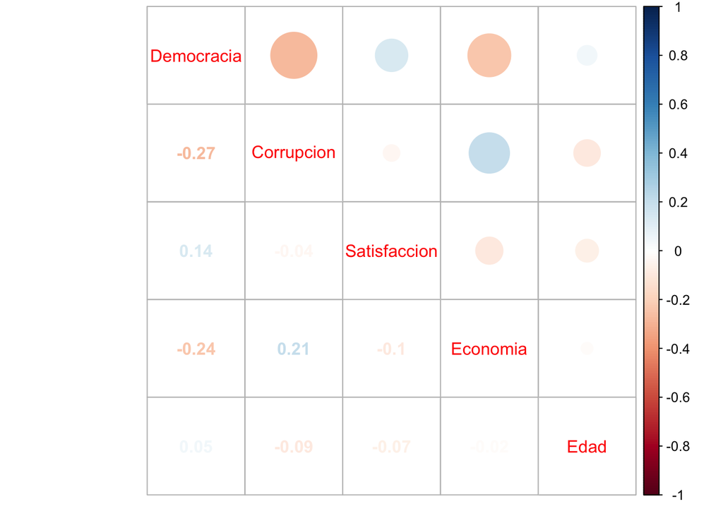

```r
corrplot.mixed(grafico_circulos)
```

En el Gráfico 1 se presentan las variables analizadas y la correlación entre estas.

La variable de percepción de corrupción en políticos correlaciona de manera baja y negativa con la satisfacción con la democracia (r=-0,27). De esto se desprende que a mayor percepción de corrupción en políticos tengan los individuos, menos satisfechos se encontrarán con la democracia. También es importante señalar que se encontró una correlación baja y positiva entre la variable de Corrupción con la percepción de la situación económica del país (r=0,21), interpretándose que mientras se perciba mayor corrupción en políticos, se tenderá a pensar que la situación económica de su país se encuentra peor.

La percepción de la situación económica del país se correlaciona de manera negativa y baja con la satisfacción con la democracia (r=-0,24), desprendiéndose que en la medida en que se percibe una peor situación económica para su país, más insatisfecho se está con la democracia.

**Tabla 2**

```r
reghelper::ICC(cor_intraclase, type = "html")
```

[1] 0.1010037

La correlación intra-clase indica qué porcentaje de la varianza de la variable dependiente se debe a la pertenencia a unidades de nivel 2. Por lo tanto, tal como se ve en la Tabla 2, la varianza de la variable Satisfacción con la Democracia se debe en un 10% a la pertenencia a un determinado país.

**Tabla 3**

```r
htmlreg(list(reg_lvl1.1,reg_lvl1.2))
```

Statistical models

|  | Model 1 | Model 2 |
| --- | --- | --- |
| (Intercept) | 3.11*** | 3.09*** |
|  | (0.05) | (0.05) |
| Corrupcion | -0.14*** | -0.13*** |
|  | (0.00) | (0.00) |
| Satisfaccion | 0.09*** | 0.08*** |
|  | (0.01) | (0.01) |
| Economia | -0.17*** | -0.16*** |
|  | (0.01) | (0.01) |
| Educacion_NivelesEducación superior/postgrados | -0.18*** | -0.19*** |
|  | (0.01) | (0.01) |
| Educacion_NivelesMedia/secundaria | -0.12*** | -0.13*** |
|  | (0.01) | (0.01) |
| Educacion_NivelesSin estudios | 0.06* | 0.08* |
|  | (0.03) | (0.03) |
| Edad_Niveles | -0.01 | -0.01** |
|  | (0.00) | (0.01) |
| SexoMujer | -0.00 | -0.05*** |
|  | (0.01) | (0.01) |
| Soborno |  | -0.12*** |
|  |  | (0.02) |
| AIC | 65980.04 | 59950.78 |
| BIC | 66071.24 | 60048.98 |
| Log Likelihood | -32979.02 | -29963.39 |
| Num. obs. | 29468 | 26458 |
| Num. groups: pais | 21 | 19 |
| Var: pais (Intercept) | 0.04 | 0.03 |
| Var: Residual | 0.55 | 0.56 |

p < 0.001; p < 0.01; p < 0.05

El modelo 2 de la Tabla 3 muestra la variación de la Satisfacción con la democracia en los países de Centro y Sur América. La variable Soborno indica que por cada unidad que esta aumente, la satisfacción con la democracia disminuye en 0.12 unidades en promedio, con un 99,9% de significación estadística para todos los individuos. En cuanto a la educación, es posible observar de manera general que en la medida en que aumenta, disminuye la satisfacción con la democracia. Las variables Sexo y Edad presentan un efecto muy pequeño por lo que no se mencionará. No obstante, en ambos es negativo.

**Tabla 4**

```r
htmlreg(list(reg_lvl2.1,reg_lvl2.2))
```

Statistical models

|  | Model 1 | Model 2 |
| --- | --- | --- |
| (Intercept) | 3.09*** | 3.66*** |
|  | (0.47) | (0.59) |
| meancor | -0.38*** | -0.38*** |
|  | (0.09) | (0.09) |
| meansas | 0.51*** | 0.41*** |
|  | (0.12) | (0.12) |
| meaneco | -0.17 | -0.22 |
|  | (0.14) | (0.12) |
| Gini | -0.01* | -0.02** |
|  | (0.01) | (0.01) |
| Cor.politic | 0.04 | -0.02 |
|  | (0.12) | (0.10) |
| AIC | 65492.22 | 61991.81 |
| BIC | 65558.19 | 62057.28 |
| Log Likelihood | -32738.11 | -30987.91 |
| Num. obs. | 28148 | 26458 |
| Num. groups: pais | 20 | 19 |
| Var: pais (Intercept) | 0.01 | 0.01 |
| Var: Residual | 0.60 | 0.61 |

p < 0.001; p < 0.01; p < 0.05

Por su parte, en el modelo 2 no se presentan variaciones significativas, salvo que el índice Gini aumenta su significación a un 99% para todos los países de Centro y Sur América.

**Tabla 5**

```r
htmlreg(list(reg_aleatoria.1,reg_aleatoria.2))
```

Statistical models

|  | Model 1 | Model 2 |
| --- | --- | --- |
| (Intercept) | 3.09*** | 3.70*** |
|  | (0.47) | (0.60) |
| Corrupcion | -0.14*** | -0.13*** |
|  | (0.00) | (0.00) |
| Satisfaccion | 0.08*** | 0.08*** |
|  | (0.01) | (0.01) |
| Economia | -0.17*** | -0.16*** |
|  | (0.01) | (0.01) |
| Gini | -0.01* | -0.02** |
|  | (0.01) | (0.01) |
| meancor | -0.24** | -0.24* |
|  | (0.09) | (0.09) |
| meansas | 0.42*** | 0.32** |
|  | (0.12) | (0.12) |
| meaneco | -0.00 | -0.06 |
|  | (0.14) | (0.13) |
| Cor.politic | 0.04 | -0.01 |
|  | (0.12) | (0.10) |
| Soborno |  | -0.14*** |
|  |  | (0.02) |
| AIC | 63313.23 | 60121.33 |
| BIC | 63403.93 | 60219.53 |
| Log Likelihood | -31645.62 | -30048.67 |
| Num. obs. | 28148 | 26458 |
| Num. groups: pais | 20 | 19 |
| Var: pais (Intercept) | 0.01 | 0.01 |
| Var: Residual | 0.55 | 0.57 |

p < 0.001; p < 0.01; p < 0.05

En la Tabla 5 se presenta la variación de la variable dependiente Satisfacción con la Democracia en función de las variables independientes de nivel 1 y nivel 2. Así, en el modelo 1 la percepción de corrupción política a nivel individual indica que por cada unidad que esta aumente, la satisfacción con la democracia disminuirá en 0.14 unidades, con un 99,9% de significación estadística para todos los individuos de todos los países de América.

Por su parte, el modelo 2, en comparación con el modelo 1, presente una leve baja en los efectos de las variables independientes de nivel 1, pero mantienen su significación estadística. En este modelo se agrega la variable soborno, que indica que por cada unidad que esta aumente, la satisfacción con la democracia disminuirá en 0.14 unidades en promedio, con un 99,9% de significación estadística para todos los individuos de todos los países. Asimismo, las variables independientes de nivel 2 disminuyen sus efectos y la variable Media por país de percepción de la corrupción (Meancor) disminuye su significación estadística a 95% y la variable Media por país de satisfacción con la vida (Meansas) baja a un 99% de significación estadística.

**Gráfico 2**

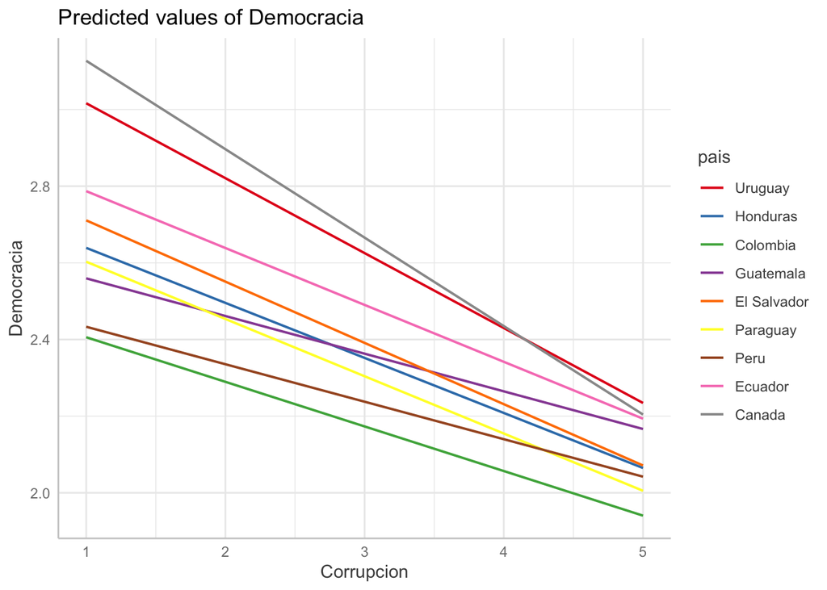

```r
plot(graf2)
```

**Tabla 6**

```r
htmlreg(list(reg_aleatoria.3,reg_aleatoria.4))
```

Statistical models

|  | Model 1 | Model 2 |
| --- | --- | --- |
| (Intercept) | 3.27*** | 3.64*** |
|  | (0.49) | (0.59) |
| Corrupcion | -0.14*** | -0.13*** |
|  | (0.00) | (0.00) |
| SexoMujer | -0.00 | -0.04*** |
|  | (0.01) | (0.01) |
| Satisfaccion | 0.08*** | 0.08*** |
|  | (0.01) | (0.01) |
| Economia | -0.17*** | -0.16*** |
|  | (0.01) | (0.01) |
| Gini | -0.01* | -0.01** |
|  | (0.01) | (0.01) |
| meancor | -0.24** | -0.25* |
|  | (0.09) | (0.10) |
| meansas | 0.43*** | 0.36** |
|  | (0.12) | (0.12) |
| meaneco | -0.09 | -0.09 |
|  | (0.14) | (0.13) |
| Cor.politic | 0.07 | 0.03 |
|  | (0.11) | (0.11) |
| Soborno |  | -0.14*** |
|  |  | (0.02) |
| AIC | 63325.85 | 60112.35 |
| BIC | 63441.28 | 60235.10 |
| Log Likelihood | -31648.92 | -30041.18 |
| Num. obs. | 28148 | 26458 |
| Num. groups: pais | 20 | 19 |
| Var: pais (Intercept) | 0.16 | 0.15 |
| Var: pais meancor | 0.01 | 0.01 |
| Cov: pais (Intercept) meancor | -0.03 | -0.03 |
| Var: Residual | 0.55 | 0.56 |

p < 0.001; p < 0.01; p < 0.05

**Tabla 7**

```r
pander(anova(reg_aleatoria.1,reg_aleatoria.1.2))
```

refitting model(s) with ML (instead of REML)

Data: data_tot2 (continued below)

|  | npar | AIC | BIC | logLik | deviance | Chisq | Df |
| --- | --- | --- | --- | --- | --- | --- | --- |
| **reg_aleatoria.1** | 11 | 63261 | 63352 | -31619 | 63239 | NA | NA |
| **reg_aleatoria.1.2** | 13 | 63211 | 63318 | -31592 | 63185 | 54.3 | 2 |

|  | Pr(>Chisq) |
| --- | --- |
| **reg_aleatoria.1** | NA |
| **reg_aleatoria.1.2** | 1.62e-12 |

**Tabla 8**

```r
htmlreg(list(reg_aleatoria.1,reg_aleatoria.1.2,reg_aleatoria.1.2.2))
```

Statistical models

|  | Model 1 | Model 2 | Model 3 |
| --- | --- | --- | --- |
| (Intercept) | 3.09*** | 3.09*** | 3.98*** |
|  | (0.47) | (0.47) | (0.56) |
| Corrupcion | -0.14*** | -0.14*** | -0.41*** |
|  | (0.00) | (0.01) | (0.09) |
| Satisfaccion | 0.08*** | 0.08*** | 0.08*** |
|  | (0.01) | (0.01) | (0.01) |
| Economia | -0.17*** | -0.17*** | -0.17*** |
|  | (0.01) | (0.01) | (0.01) |
| Gini | -0.01* | -0.01* | -0.01* |
|  | (0.01) | (0.01) | (0.01) |
| meancor | -0.24** | -0.22* | -0.46*** |
|  | (0.09) | (0.09) | (0.12) |
| meansas | 0.42*** | 0.40*** | 0.40*** |
|  | (0.12) | (0.12) | (0.12) |
| meaneco | -0.00 | 0.02 | 0.01 |
|  | (0.14) | (0.14) | (0.14) |
| Cor.politic | 0.04 | 0.05 | 0.05 |
|  | (0.12) | (0.13) | (0.13) |
| Corrupcion:meancor |  |  | 0.07** |
|  |  |  | (0.02) |
| AIC | 63313.23 | 63261.21 | 63261.51 |
| BIC | 63403.93 | 63368.40 | 63376.94 |
| Log Likelihood | -31645.62 | -31617.60 | -31616.76 |
| Num. obs. | 28148 | 28148 | 28148 |
| Num. groups: pais | 20 | 20 | 20 |
| Var: pais (Intercept) | 0.01 | 0.03 | 0.02 |
| Var: Residual | 0.55 | 0.55 | 0.55 |
| Var: pais Corrupcion |  | 0.00 | 0.00 |
| Cov: pais (Intercept) Corrupcion |  | -0.01 | -0.00 |

p < 0.001; p < 0.01; p < 0.05

**Plot**

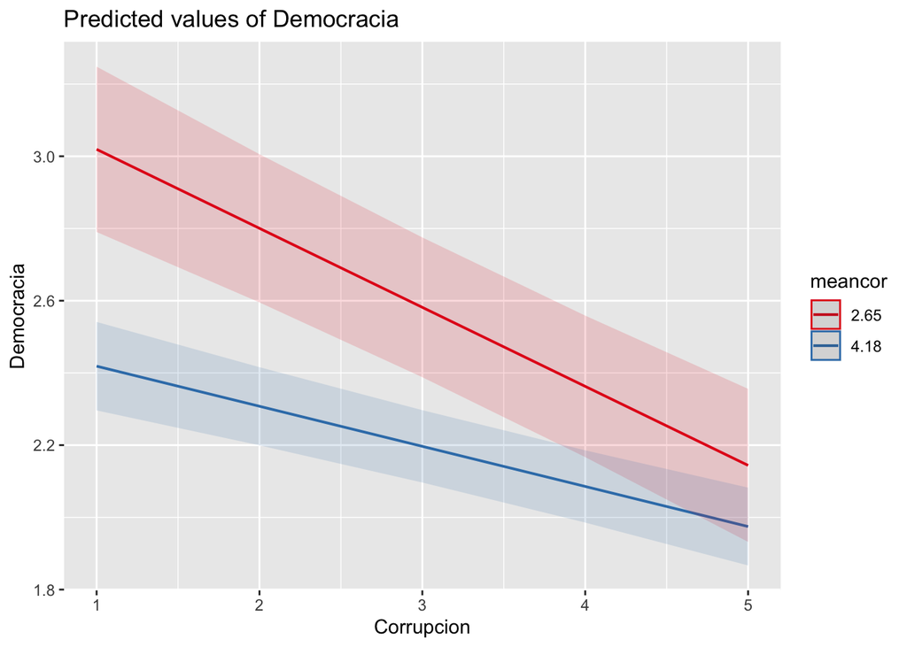

```r
plot_model(reg_aleatoria.1.2.2, type = "int")
```

# 6 Conclusiones

Los principales hallazgos del estudio, en términos generales, señalan que, a mayor percepción de una peor economía, una baja satisfacción con la vida y una percepción de mayor corrupción política, se tiene una menor satisfacción con la democracia. Esto se expresa en que las variables Satisfacción -con la vida- aumenta en 0.09 unidades la satisfacción con la democracia y la variable Economía disminuye en 0.17 unidades la satisfacción con la democracia en promedio, por cada unidad que ellas aumenten. Por su parte, en la medida en que la variable Corrupción aumenta en una unidad, disminuye la satisfacción con la democracia en 0.14.

Con respecto a las ventajas de utilizar el método multinivel, este permite contrastar hipótesis entre niveles, por lo que se puede evidenciar si, en este caso, la Satisfacción con la Democracia varía en mayor medida por variables individuales o por variables contextuales, o incluso, si es que las variables individuales están condicionadas por situaciones contextuales. De esta manera, el método multinivel permite ir más allá de los resultados tradicionales que entrega la regresión estadística, enfocándose en el contexto situacional de cada individuo.

Dentro de las limitaciones y dificultades de este estudio encontramos las diferencias de cuestionarios entre Canada y Estados Unidos en comparación con el resto de América por lo que se realizó un análisis diferenciado entre modelos “Norte-centro-sur” (incluyendo a Canadá y EE.UU.) y “Centro-sur” (sin estos 2 países) ante la ausencia de la pregunta por la variable “soborno” en Canadá y EE.UU. Además, el no contar con datos actualizados de los países Nicaragua y Venezuela dificultó la viabilidad de este estudio, puesto que actualmente las realidades de esos países pudieron sufrir cambios respecto a los niveles de cómo los ciudadanos perciben la democracia y su satisfacción con la vida.

Finalmente pensando en futuras investigaciones en el área, y en línea con lo ya mencionado, se recomienda proceder con cautela en este tipo de análisis dado las diferencias internas entre los países de América, y también las diferencias que presentan en cuanto a producción de datos e indicadores que dificultan su integración dentro de un modelo a nivel continental.

# Bibliografía

Alister, C., Cea, C., & Guerrero, A. (n.d.). *Democracia en latinoamérica Qué factores influyen en la satisfacción y apoyo a la democracia?* (Original work published)

Bohn, S. R. (2012). Corruption in Latin America: Understanding the Perception-Exposure Gap. *Journal of Politics in Latin America*, *4*(3), 67–95. https://doi.org/10.1177/1866802X1200400303 (Original work published)

Diamond, L. (1992). *Reconsideración del nexo entre desarrollo económico y democracia*. (Original work published)

DiPrete, T. A., & Forristal, J. D. (1994). Multilevel Models: Methods and Substance. *Annual Review of Sociology*, *20*(1), 331–357. https://doi.org/10.1146/annurev.so.20.080194.001555 (Original work published)

Garretón Merino, M. A. (2014). *Las ciencias sociales en la trama de Chile y América Latina: Estudios sobre transformaciones sociopolíticas y movimiento social* (Primera edición). Santiago de Chile: LOM Ediciones. (Original work published)

Latinobarómetro, C. (2018). *Informe2018*. (Original work published)

Martín, F. A. (1983). Perspectiva cualitativa-Perspectiva cuantitativa en la metodología sociológica. *Reis*, (22), 53. https://doi.org/10.2307/40182982 (Original work published)

Morales Quiroga, M. (2009). Corrupción y democracia: América Latina en perspectiva comparada. *Centro de Investigación Y Docencia Económicas, División de Administración Pública*, *18*(2), 205–252. (Original work published)

Olmeda, J. C. (2019). *Qué hay detrás de la (in)satisfacción con la democracia en América Latina?* (Original work published)

Ramos, M., & Álvarez, F. J. (2019). El control de la corrupción en América Latina: agenda política, judicialización e internacionalización de la lucha contra la corrupción. *Documentos de Trabajo*. https://doi.org/10.33960/issn-e.1885-9119.DT11 (Original work published)

Sánchez, J. (2004). *Por Qué se deslegitima la democracia? El desorden democrático*. (Original work published)